# Práctica 2. Visualización de datos

Introducción a la Ciencia de Datos. Máster en Ciencia de Datos- UV

Marino Fernández Pérez

2026-10-26

Práctica 2

# 1 Ejercicio 1

## Carga el fichero `weatherAUS.RData` utilizando lo aprendido en la práctica 1

Para poder trabajar con el dataset, es necesario utilizar la función ya vista y utilizada en la práctica 1 `load()`.

```
'data.frame':   863 obs. of  24 variables:
 $ Date         : Date, format: "2009-03-23" "2014-12-08" "2010-06-07" "2013-06-27" ...
 $ Location     : chr  "Richmond" "Albury" "Launceston" "Sale" ...
 $ MinTemp      : num  14.2 13.9 0.4 0.2 10.2 9 8.6 24 12.4 24.4 ...
 $ MaxTemp      : num  29.8 27.7 13.1 15.1 20.7 17.2 23.9 34.2 18 31.9 ...
 $ Rainfall     : num  0.2 1.4 0 0.2 0 1 0 0 2 18.4 ...
 $ Evaporation  : chr  "12.2" NA NA "1.2" ...
 $ Sunshine     : chr  NA NA NA "7.3" ...
 $ WindGustDir  : chr  "NE" "W" "S" "NW" ...
 $ WindGustSpeed: int  28 37 19 17 NA 44 63 41 NA 31 ...
 $ WindDir9am   : chr  NA "ENE" NA "WNW" ...
 $ WindDir3pm   : chr  "E" "NW" "SSE" "NNW" ...
 $ WindSpeed9am : int  0 6 0 9 6 22 13 15 6 11 ...
 $ WindSpeed3pm : int  11 22 4 7 13 30 39 15 35 17 ...
 $ Humidity9am  : int  92 74 98 93 64 71 62 71 84 83 ...
 $ Humidity3pm  : int  36 42 57 57 40 63 22 56 61 68 ...
 $ Pressure9am  : num  1017 1008 1028 1024 1025 ...
 $ Pressure3pm  : num  1014 1007 1026 1021 1020 ...
 $ Cloud9am     : int  NA NA NA 2 5 3 2 6 7 6 ...
 $ Cloud3pm     : int  NA 5 NA 3 7 8 1 3 3 6 ...
 $ Temp9am      : num  18.3 20.9 4.3 3.7 13 12.8 15.4 29.7 15.3 27.9 ...
 $ Temp3pm      : num  29.5 26.4 11.9 14.3 18.7 14.6 23.5 32.1 17.5 30.9 ...
 $ RainToday    : chr  "No" "Yes" "No" "No" ...
 $ RISK_MM      : num  0 0 0.4 0 0 0.2 0 0 1.6 24.2 ...
 $ RainTomorrow : chr  "No" "No" "No" "No" ...
 - attr(*, "spec")=
  .. cols(
  ..   Date = col_date(format = ""),
  ..   Location = col_character(),
  ..   MinTemp = col_double(),
  ..   MaxTemp = col_double(),
  ..   Rainfall = col_double(),
  ..   Evaporation = col_character(),
  ..   Sunshine = col_character(),
  ..   WindGustDir = col_character(),
  ..   WindGustSpeed = col_integer(),
  ..   WindDir9am = col_character(),
  ..   WindDir3pm = col_character(),
  ..   WindSpeed9am = col_integer(),
  ..   WindSpeed3pm = col_integer(),
  ..   Humidity9am = col_integer(),
  ..   Humidity3pm = col_integer(),
  ..   Pressure9am = col_double(),
  ..   Pressure3pm = col_double(),
  ..   Cloud9am = col_integer(),
  ..   Cloud3pm = col_integer(),
  ..   Temp9am = col_double(),
  ..   Temp3pm = col_double(),
  ..   RainToday = col_character(),
  ..   RISK_MM = col_double(),
  ..   RainTomorrow = col_character()
  .. )
```

A simple vista, el conjunto de datos contiene 863 observaciones y 24 variables que lo caraceterizan, relacionadas con las condiciones meteorológicas de distintas localidades a lo largo de los años, y de distinto tipo (numéricas, categóricas…)

No obstante, se pueden observar **valores faltantes** en algunas de ellas, así como variables numéricas almacenadas como carácteres en `Evaporation` y `Sunshine`.

## 1.1 Crea un objeto ggplot denominado grafico1 en el que esté definido el conjunto de datos ds alojado en el fichero weatherAUS.RData y un aesthetics en el que en el eje x esté definida la variable MinTemp y en el eje y esté definida la variable MaxTemp.

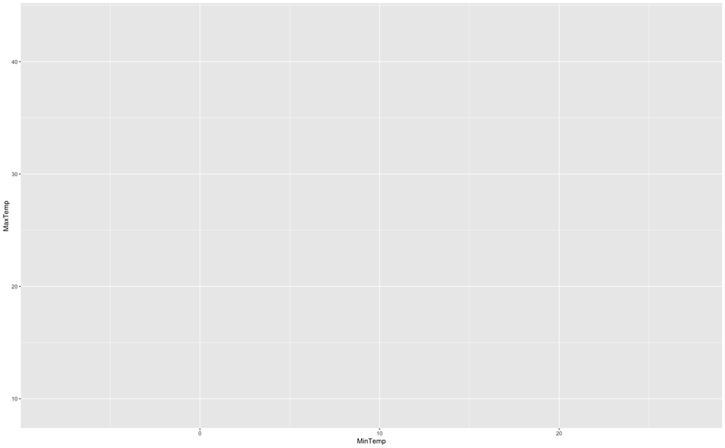

## 1.2 Añade una capa que defina el objeto geométrico necesario para construir un gráfico de dispersión de las variables MinTemp y MaxTemp.

No obstante, la relación no es perfecta ya que hay dispersión en los puntos.

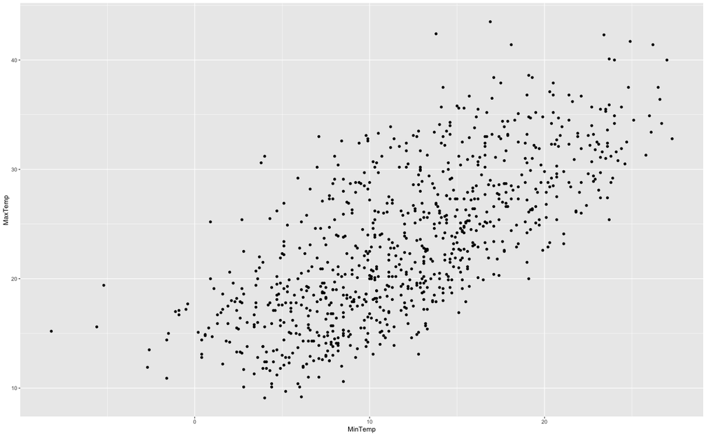

## 1.3 Genera ahora el mismo gráfico y almacénalo en grafico2 pero define el aesthetics para visualizar las variables MinTemp y MaxTemp en los ejes de la gráfica y la variable categórica RainTomorrow como el color. A partir del objeto grafico2, representa un gráfico de dispersión en el que se muestren los puntos con el color del punto correspondiente a la variable RainTomorrow.

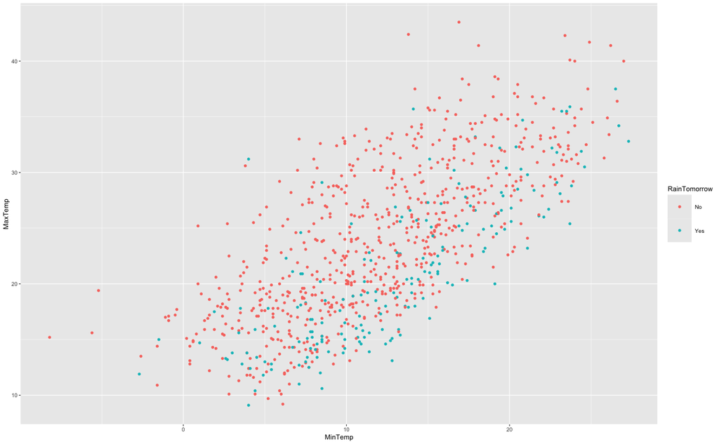

## 1.4 Añade a grafico2 una capa para incluir un título con ggtitle() y almacénalo en grafico3.

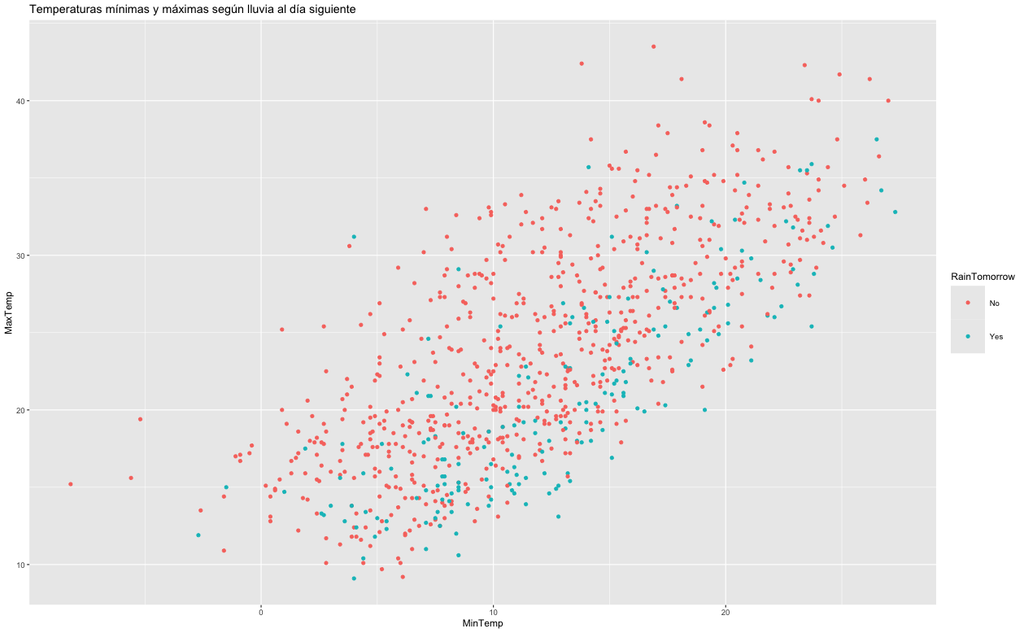

## 1.5 Almacena en formato pdf el gráfico resultante en un fichero denominado Ejercicio1.pdf.

# 2 Ejercicio 2

## 2.1 Utilizando ggplot haz un grafico de dispersión en el que representes las variables Temp9am y Pressure9am en los ejes x e y respectivamente.

Como seguimos trabajando con el mismo dataset del ejercicio anterior, no es necesario cargarlo.

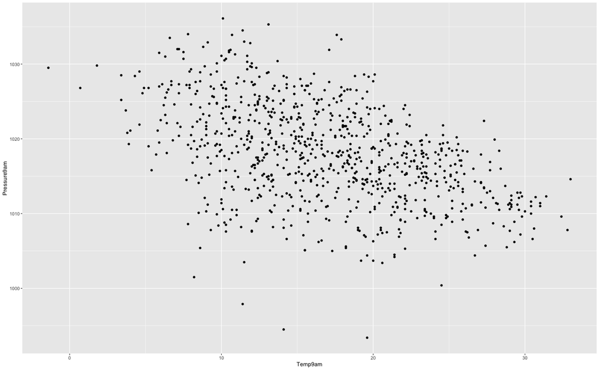

## 2.2 Modifica el gráfico anterior para incluir información categórica proporcionada por la variable RainToday con la forma del punto.

Añadimos la variable categórica `RainToday` mediante el atributo estético `shape`, asignando una forma diferente a los puntos según si se han registrado precipitaciones ese día.

De esta manera, incorporamos una tercera variable al diagrama de dispersión sin modificar los ejes, lo que nos permite explorar si existen diferencias en la distribución de la temperatura y la presión atmosférica entre los días con lluvia y sin lluvia.

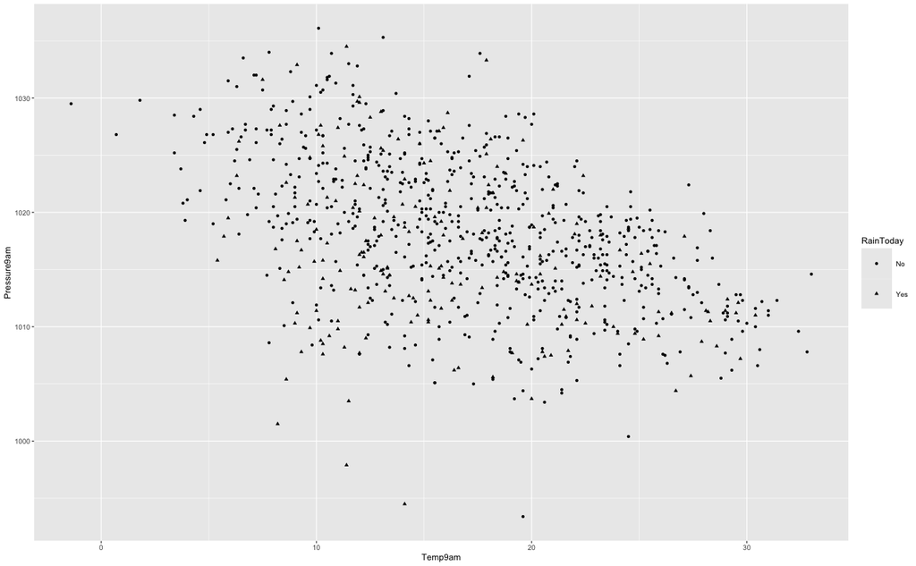

## 2.3 Modifica el gráfico anterior para incluir información categórica proporcionada por la variable RainToday con el color del punto. ¿Con qué representación (color o forma) se observa mejor la información que introduce la variable RainToday?

En esta ocasión, utilizamos el atributo estético `color` para diferenciar los registros según la variable `RainToday`, asignando un color distinto a los días con lluvia y sin lluvia.

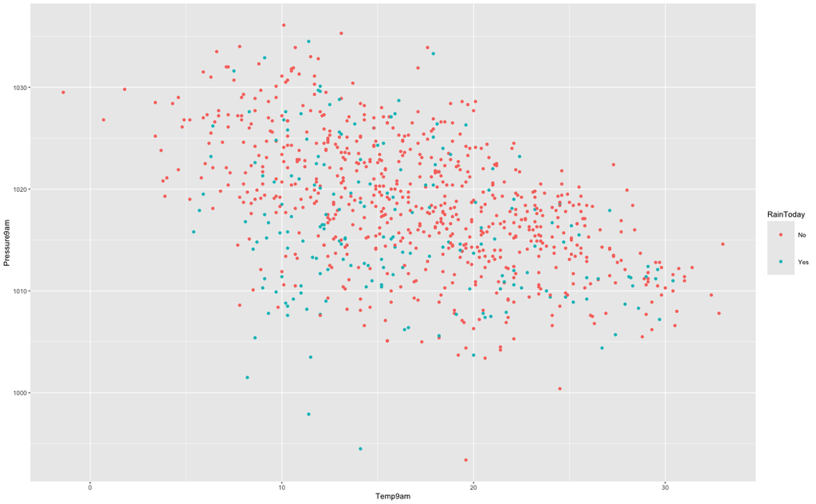

Comparando ambas representaciones, consideramos que **el color permite identificar más fácilmente las categorías**, ya que facilita distinguir visualmente los distintos grupos de observaciones. Por su parte, la representación mediante formas también permite diferenciarlos, aunque puede resultar menos clara cuando existe una elevada concentración de puntos.

En general, el color permite distinguir más fácilmente las categorías, especialmente cuando tenemos muchos puntos.

## 2.4 Añade títulos explicativos al gráfico anterior (debe aparece un título, subtítulo, leyendas e información de las variables representadas en los ejes).

Finalmente, utilizamos la función `lab()`, que permite incorporar lo solicitado en el enunciado como texto en la gráfica. Además, también permite modificar el nombre de la leyenda para hacerla aún más representativa y facil para identificar los días con lluvia y sin lluvia.

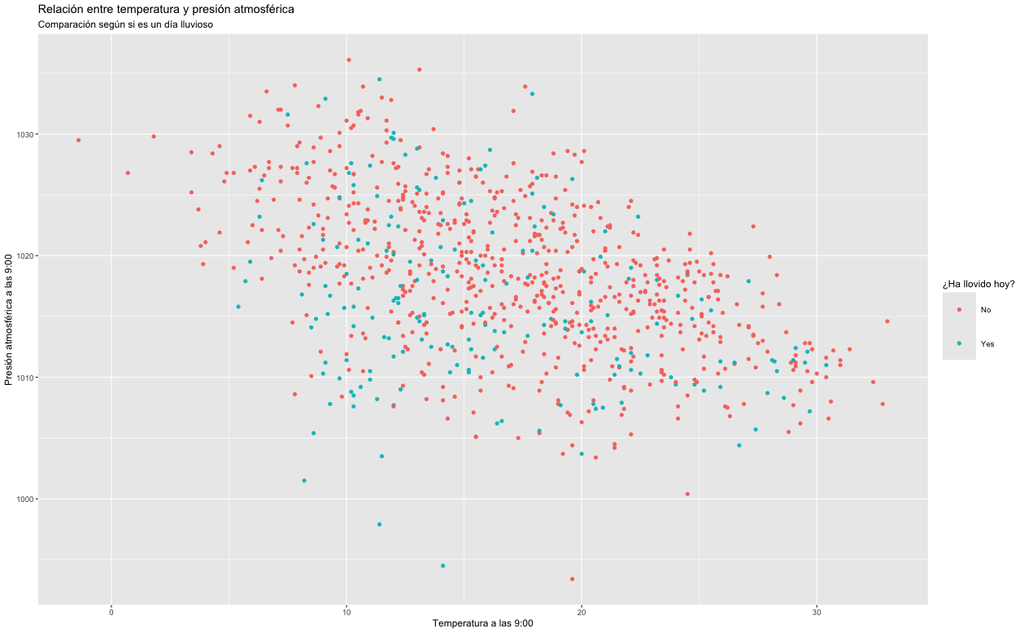

De esta manera, a partir de un gráfico que ya era claro, conseguimos una representación aún más completa y facil de entender, que permite interpretar las variables representadas de manera informal y sin nesidad de consultar el código utilizado.

## 2.5 Almacena en formato pdf el gráfico resultante en un fichero denominado Ejercicio2.pdf.

# 3 Ejercicio 3

## 3.1 Carga el fichero iris.tidy.Rdata utilizando lo aprendido en la práctica 1.

En primer lugar, cargamos el fichero `iris_tidy.Rdata` mediante la función `load()`, almacenado en la carpeta `./data`, que utilizaremos para definir los scatter plot de este ejercicio.

## 3.2 Utiliza la función str() para ver qué variables contiene el dataset.

A partir de la función `str()`, visualizamos rápidamente la estructura del dataset, sus variables y tipos correspondientes.

```
'data.frame':   600 obs. of  4 variables:
 $ Species: Factor w/ 3 levels "setosa","versicolor",..: 1 1 1 1 1 1 1 1 1 1 ...
 $ Part   : Factor w/ 2 levels "Petal","Sepal": 2 2 2 2 2 2 2 2 2 2 ...
 $ Measure: chr  "Length" "Length" "Length" "Length" ...
 $ Value  : num  5.1 4.9 4.7 4.6 5 5.4 4.6 5 4.4 4.9 ...
```

El dataset está compuesto por 600 observaciones y 4 variables que caracterizan a cada registro.

## 3.3 Crea un objeto ggplot denominado iris.grafico1 en el que esté definido el conjunto de datos iris.tidy alojado en el fichero iris.tidy.RData y un aesthetics en el que en el eje x esté definida la variable Species y en el eje y esté definida la variable Value.

Creamos el objeto iris.grafico1 utilizando ggplot(), asociando la variable categórica Species al eje X y la variable numérica Value al eje Y.

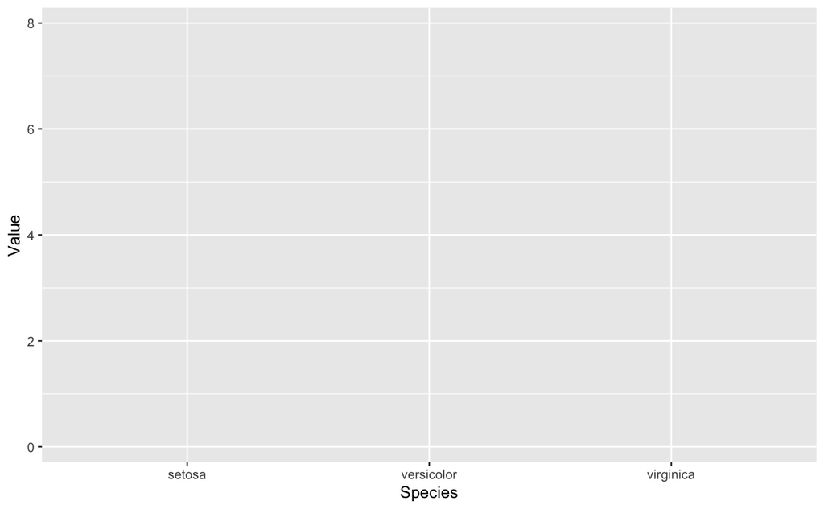

Al igual que ocurría en el ejercicio 1, aún no se ha añadido ninguna capa geométrica, por lo que se obtiene un gráfico vacío con los ejes definidos en el que aún no se ha especificado como se representarán las observaciones registradas en el dataset.

## 3.4 Añade una capa que defina el objeto geométrico necesario para construir un gráfico de dispersión de las variables Species y Value.

Añdimos la capa mediante `geom_point()`.

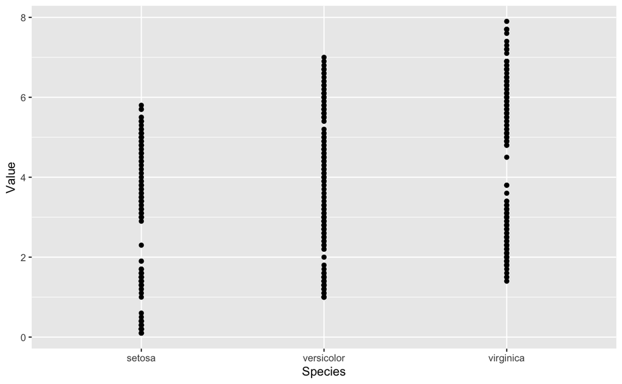

El gráfico obtenido representa la distribución de las mediciones tomadas para las tres especies de iris que se encuentran recopiladas en el dataset.

En general, `virginica` es la especia de iris que presenta valores más elevados, seguida de `versicolor` y finalmente `setosa`. No obstante, el problema en esta representación es claro ya que, en `Value`, se está considerando conjuntamente las longitudes y anchuras de los pétalos y los sépalos. Además, se observa solapamiento entre puntos, debido a que varias observaciones comparten las mismas coordenadas en el gráfico y se representan unas encima de otras, consiguiendo que la lectura del gráfico sea mucho más costosa.

## 3.5 Modifica el aesthetics de iris.grafico1 para visualizar la variable categórica Part y almacénalo en iris.grafico2. A partir del objeto iris.grafico2, representa un gráfico de dispersión en el que se muestren los puntos dados por las variables Species y Value, y el color del punto se corresponda con el valor de la variable Part.

Partiendo de **iris.grafico1**, añadimos `color = Part` dentro de `aes()` para que **ggplot2** asigne automáticamente un color a cada categoría y añada la leyenda correspondiente para poder interpretarlo.

Como vimos con `str()` anteriormente, **Part** es una variable tipo factor que diferencia las mediciones correspondientes a pétalos y sépalos. De esta manera, incluir esta división permite comprobar que puntos se corresponden a uno u otro.

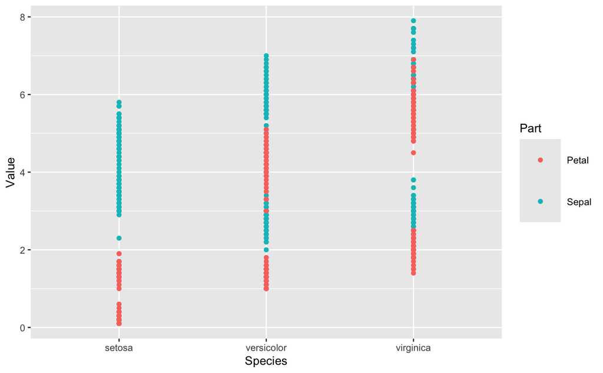

A partir del gráfico mejorado, observamos que, en `setosa`, las mediciones de los pétalos se corresponden a valores más pequeños que las de los sépalos, mientras que en `versicolor` y `virginica` hay un mayor solapamiento entre ambas categorías. Si tratasemos de resolver un problema de clasificación a partir de este conjunto de datos, con este gráfico estariamos extrayendo un rango distintivo de la especie `setosa` respecto al resto, al mostrar un registro de valores distinto.

Por otro lado, la especie `virginica` alcanza los valores máximos más elevadas. Gracias a la diferenciacion mediante colores, la interpretación del gráfico anterior es más informativa, aunque aún se sigue mezclando longitud y anchura, lo que dificulta su comparación.

## 3.6 Incluye información de la variable Measure haciendo dos gráficos de dispersión (dispuestos en filas) con facet_grid(), como en el apartado de introducción, para los dos valores que toma la variable Measure. Prueba a cambiar la disposición de los gráficos para que sea en columnas ¿Qué disposición, en filas o en columnas, permite comparar mejor los valores de las dos variables?

Recordamos que representa la variable `Measure` mediante la función `str()`, donde su función consiste en identificar si el valor representado se corresponde a la longitud **“Length”** o la anchura **“Width”**.

```
'data.frame':   600 obs. of  4 variables:
 $ Species: Factor w/ 3 levels "setosa","versicolor",..: 1 1 1 1 1 1 1 1 1 1 ...
 $ Part   : Factor w/ 2 levels "Petal","Sepal": 2 2 2 2 2 2 2 2 2 2 ...
 $ Measure: chr  "Length" "Length" "Length" "Length" ...
 $ Value  : num  5.1 4.9 4.7 4.6 5 5.4 4.6 5 4.4 4.9 ...
```

Mediante `facet_grid()` separamos las dos mediciones en dos gráficos independientes, manteniendo los colores para diferenciar entre sépalo y pétalo.

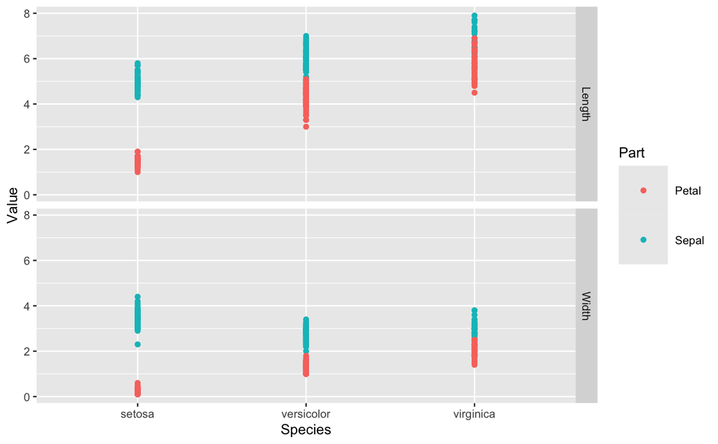

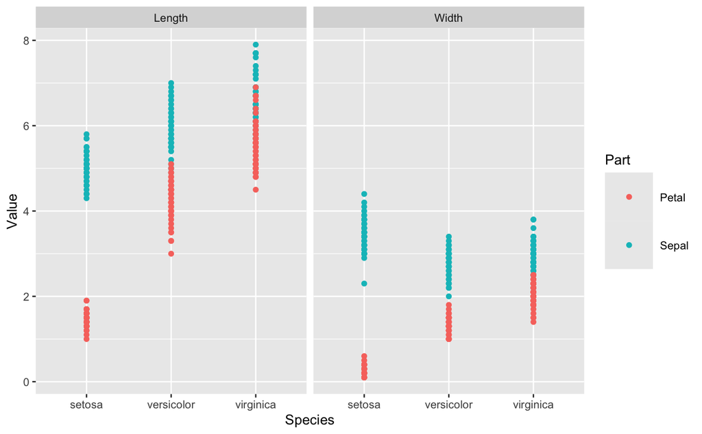

Si diferenciamos ambas disposiciones, la **representación en filas facilita la comparación entre especies** ya que no reduce el espacio de representación de cada gráfico como sí lo hace la disposición en columnas (achatada), permitiendo observar mejor la distribución de los puntos. No obstante, ambas disposiciones son correctas ya que muestran la misma información, aunque aún sigue habiendo solapamiento.

Utilizando la representación por filas para el analisis de ambos gráficos, se observa que, en general, las longitudes presentan valores superiores a las anchuras. Además, la especie `setosa` destaca sobre el resto por tener pétalos consideráblemente más pequeños tanto en anchura como en largura, mientras que `virginica` presenta los de mayor longitud.

## 3.7 Cambia ahora la capa geom_point() del gráfico anterior por la capa geom_jitter(). ¿Qué diferencia observas?

Para resolver el problema de solapamiento presente hasta ahora, hasta ahora, con `geom_point()` se estaba representando la posición exacta de cada punto, mientras que la función `geom_jitter()` va a tratar de “solucionar” este problema añadiendo pequeñas variaciones aleatorias a las posiciones de los puntos.

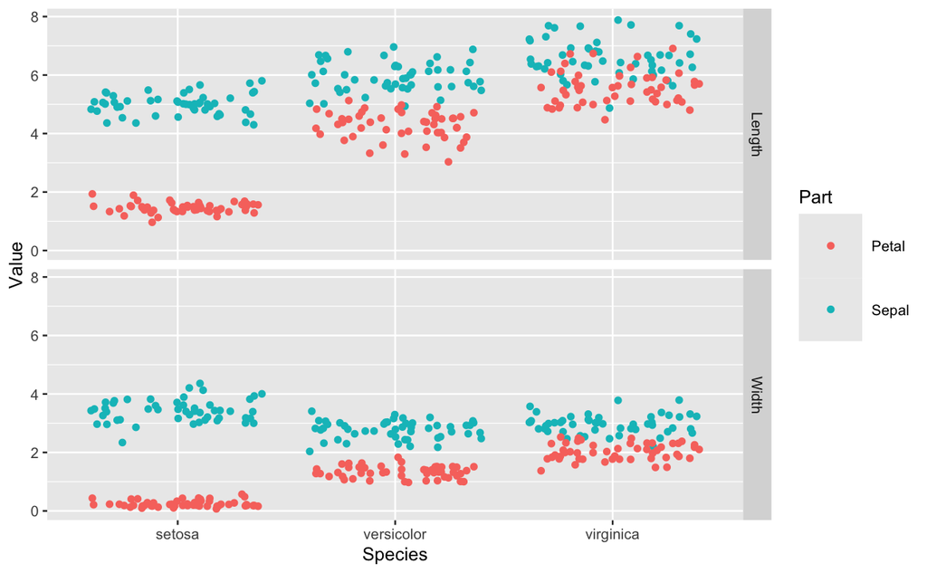

En la práctica, el gráfico resultante muestra una gran mejora en la visualización de los datos, ya que se reduce el problema de solapamiento de puntos que aparecía en el gráfico anterior, del cual ya estabamos extrayendo bastante informacion a cerca del conjunto de datos.

Gracias a ello, y aunque el patrón extraido anteriormente se mantiene, podemos observar con mayor claridad las diferencias entre especies y entre las mediciones de pétalos y sépalos. Por ejemplo, en el gráfico anterior, la anchura de los pétalos y sépalos para `versicolor` se representaban agrupadas en columnas verticales, con numerosos registros superpuestos. Ahora, gracias a los pequeños desplazamientos, podemos distinguir mejor las observaciones individuales y su distribución.

Por tanto, `geom_jitter()` es más adecuado para este caso, ya que mejora la legibilidad del gráfico sin modificar los valores originales del conjunto de datos.

## 3.8 Almacena en formato pdf el gráfico resultante en un fichero denominado Ejercicio3.pdf.

# 4 Ejercicio 4

## 4.1 Carga el fichero Ejercicio4_Data.Rdata. Examina las variables que tiene dicho dataset.

```
[1] "DatosEjer4"
```

```
'data.frame':   200 obs. of  3 variables:
 $ Fecha     : Date, format: "2002-01-01" "2002-02-01" "2002-03-01" "2002-04-01" ...
 $ Fabricante: Factor w/ 2 levels "Microsoft","Apple": 1 1 1 1 1 1 1 1 1 1 ...
 $ Ventas    : num  75 67.1 75.5 77.4 68.1 ...
```

El conjunto de datos contiene 200 observaciones y 3 variables:

- **Fecha**, de tipo fecha (`Date`)
- **Fabricante**, variable categórica de tipo factor con dos niveles (Microsoft y Apple),
- y **Ventas**, variable numérica.

Estos datos permitirán analizar y comparar la evolución temporal de las ventas de ambos fabricantes.

## 4.2 Representa un gráfico de puntos, en el que se muestre la fecha en el eje x y las ventas en el eje y. Queremos que los datos de cada fabricante sean de un color distinto. ¿Es este gráfico válido para evaluar la evolución de las ventas de cada fabricante?

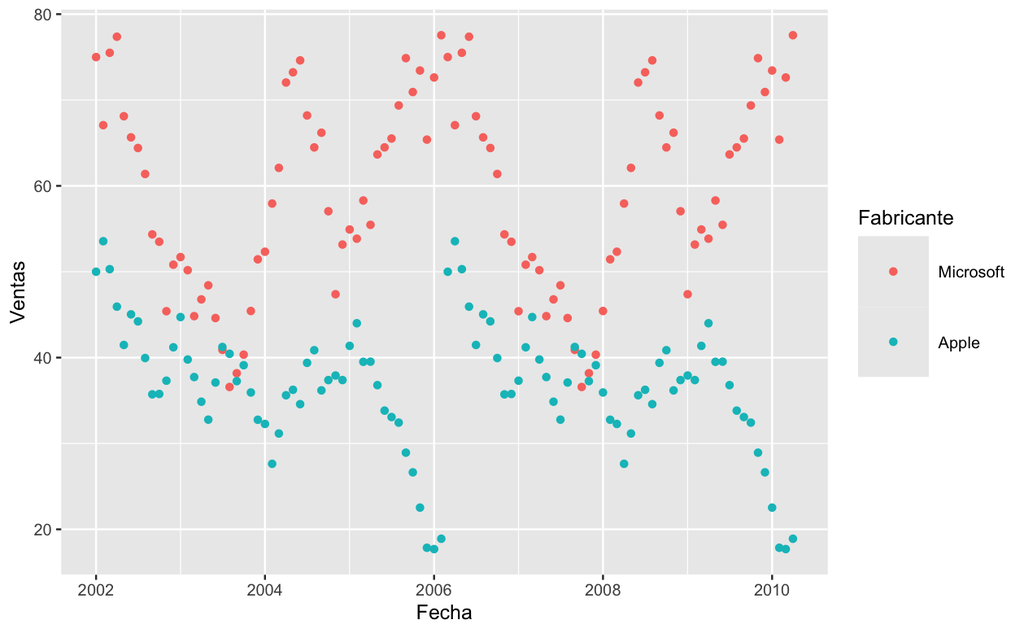

El gráfico obtenido a partir de la representación indicada muestra las ventas mensuales de ambos fabricantes entre 2002 y 2010. A partir de él se observa que Microsoft presenta generalmente más ventas, aunque hay algunos periodos en los que las ventas de ambos se aproximan. Además, existen patrones temporales respecto a las ventas, donde, por ejemplo, para Apple, se tiene una caida tanto en 2005-2006 como en 2009-2010, mientras que para Microsoft, ocurre en 2003-2004 y 2007-2008.

Sin embargo, el gráfico de dispersión **no es el más adecuado para analizar su evolución temporal**, ya que los puntos no están conectados y su interpretación es más compleja.

## 4.3 Representa un gráfico como el anterior en el que se muestre la línea que une los puntos que antes has representado.

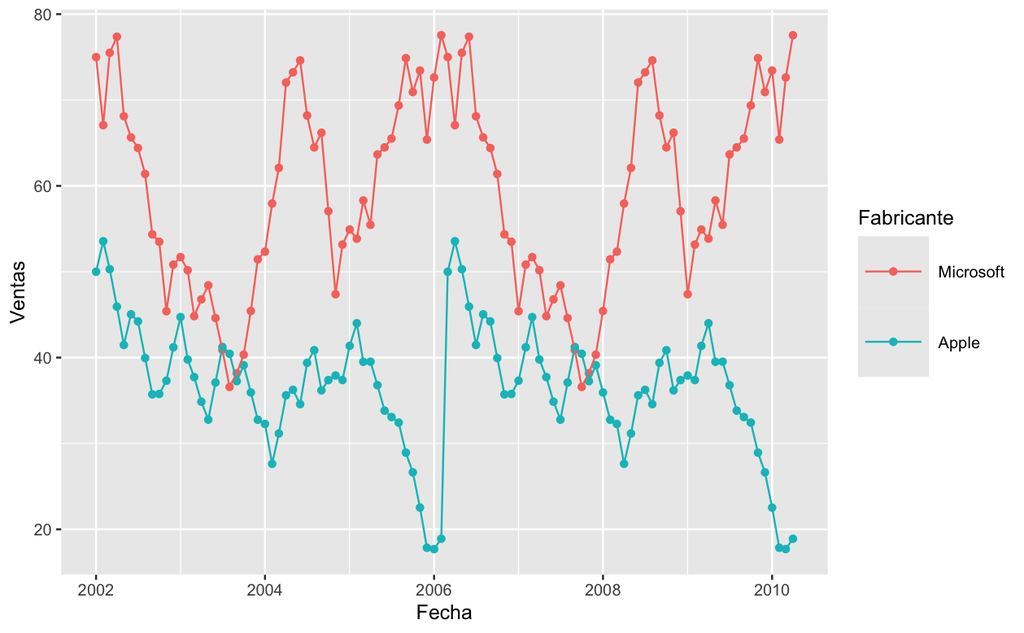

Al añadir `geom_line()`, las observaciones de cada fabricante se visualizan cronológicamente, facilitando la interpretación de la evolución de sus ventas.

Esta reprensetación **confirma las tendencias identificadas anteriormente**, pero con mayor claridad. Por tanto, **el gráfico de líneas es más adecuado para analizar series temporales**, ya que facilita la identificación de tendencias y variaciones respecto al gráfico de dispersión.

## 4.4 Modifica el gráfico anterior para que la tendencia de cada fabricante este trazada con un tipo de línea diferente.

Utilizando **aesthetic**, añadimos `linetype = Fabricante` para que cada compañía tenga un tipo de línea diferente, facilitando más aún la interpretación del gráfico. En este caso, la evolución temporal de Microsoft se representa con una línea continua, mientras que la de Apple, con una línea discontinua.

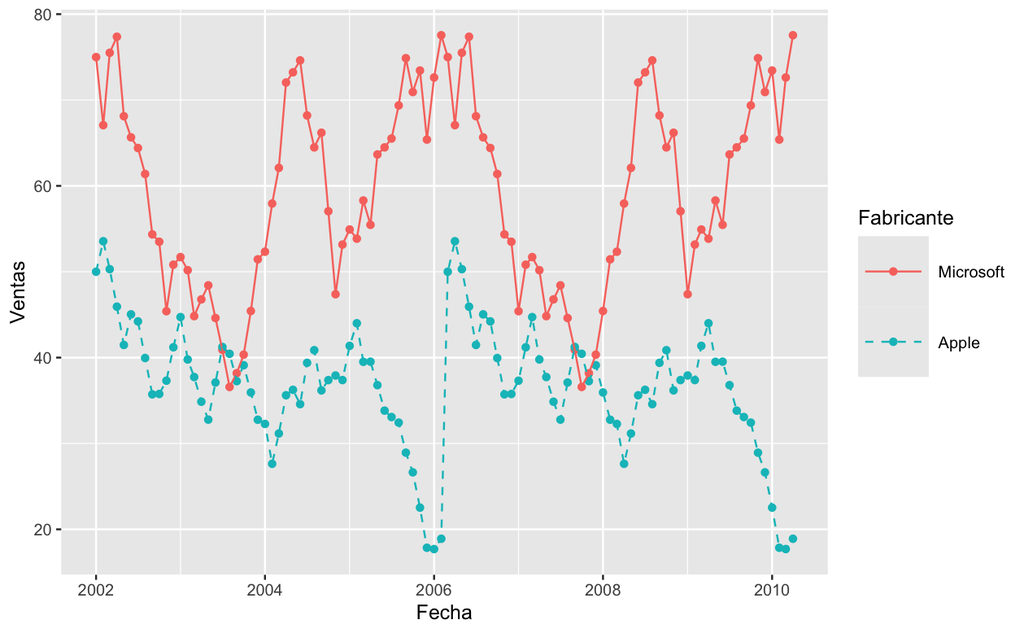

## 4.5 Añade el siguiente título al gráfico “Ventas mensuales de diferentes compañías tecnológicas”.

Al igual que en el ejercicio 2, utilizamos `labs()` para asignar un título al gráfico.

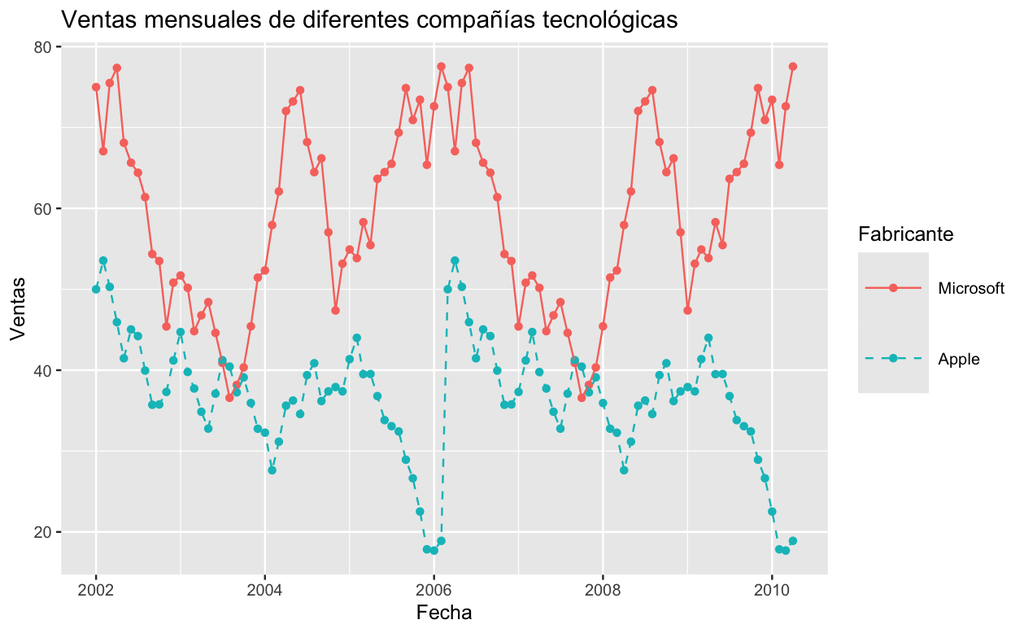

## 4.6 Almacena en formato pdf el gráfico resultante en un fichero denominado Ejercicio4.pdf.

# 5 Ejercicio 5

## 5.1 Carga el fichero Experimento.Rdata. Examina las variables que tiene dicho dataset.

```
[1] "Experimento"
```

```
'data.frame':   6 obs. of  4 variables:
 $ Complemento : Factor w/ 2 levels "OJ","VC": 1 1 1 2 2 2
 $ Dosis       : num  0.5 1 2 0.5 1 2
 $ Altura      : num  13.23 22.7 26.06 7.98 16.77 ...
 $ Error_Altura: num  4.46 3.91 2.66 2.75 2.52 ...
```

El conjunto de datos contiene **6 observaciones** y **4 variables**:

- `Complemento`: variable categórica que identifica el tipo de complemento utilizado (`OJ` o `VC`).
- `Dosis`: variable numérica que indica la cantidad de complemento.
- `Altura`: variable numérica que recoge la altura registrada para cada complemento y dosis.
- `Error_Altura`: variable numérica que representa el margen de error asociado a cada medida de altura.

Por tanto, el dataset recoge los resultados de un experimento en el que se estudia **cómo varía la altura en función de la dosis y del tipo de complemento**, considerando también el posible error que pueda haber en las las mediciones.

## 5.2 Representa un gráfico de puntos, en el que se muestre la Dosis en el eje x y la Altura en el eje y. Queremos que los datos de cada Complemento se representen en una línea diferente con diferentes trazos. Hazlo incluyendo las opciones de tipo de línea y forma del punto dentro del aes() de la capa ggplot.

Representamos la altura en función de la dosis para cada complemento, diferenciándolos mediante colores, tipos de línea y formas de puntos. Para ello, utilizamos las funciones `geom_point()` y `geom_line()`, definiendo los atributos estéticos dentro de `aes()`.

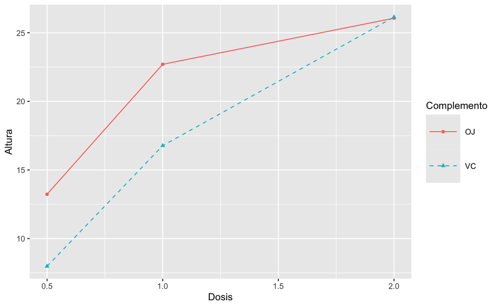

A partir del gráfico obtenido, observamos que la altura aumenta conforme se incrementa la dosis en ambos complementos. La principal diferencia es que `OJ` cuenta con valores superiores a `VC` para las dosis de 0.5 y 1, mientras que con una dosis de 2 ambos alcanzan prácticamente la misma altura.

## 5.3 Crea otro gráfico añadiendo al gráfico anterior barras de error en cada punto. El error viene dado por la variable Error_Altura.

Añdimos `geom_errorbar()` para representar el margen de error registrado en `Error_Altura`. Ademñas, se utiliza el parámetro `width = 0.05` ya que, por defecto, las barras eran demasiado grandes y dificultaban la interpretación.

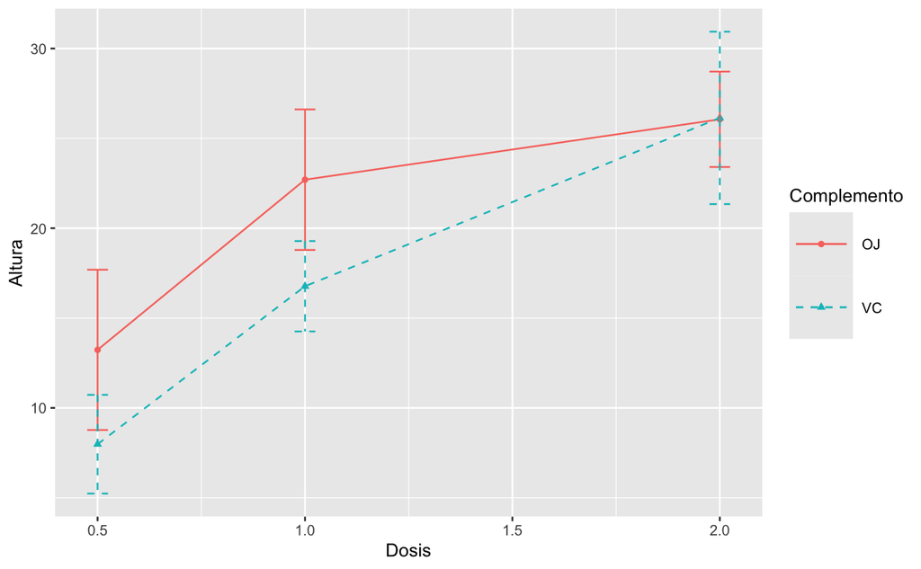

Observamos que los intervalos de error de ambos complementos se solapan en la mayoría de dosis, especialmente en la dosis de 2. Por tanto, aunque `OJ` presenta mayores alturas en las dosis inferiores, el solapamiento de las barras de error indica que estas diferencias deben interpretarse con cuidado, ya que los intervalos de ambos complementos comparten parte de sus valores.

## 5.4 Crea otro gráfico, como el anterior (idéntico), pero en este caso no puedes incluir el tipo de línea y el tipo de punto en aes() de la capa ggplot. Además queremos que la paleta de colores sea en tonos de rojos (scale_color_brewer).

El gráfico obtenido es el mismo, aunque su estética no se define en el `aes()` general de `ggplot()`, sino en `geom_point()` y `geom_line()`.

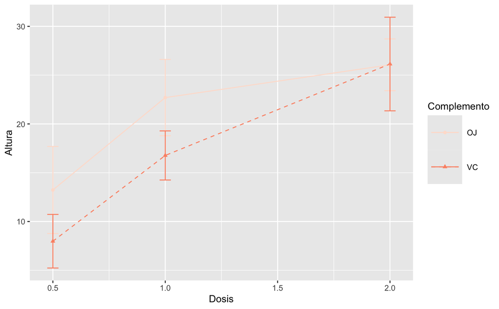

## 5.5 Almacena en formato pdf el gráfico resultante en un fichero denominado Ejercicio5.pdf.

# 6 Ejercicio 6

## 6.1 El fichero iceRiver.RData contiene información del caudal de dos ríos islandeses medidos a diarios durante 3 años. Puedes obtener información detallada de las variables usando > ?tseries::ice.river

```
[1] "ice.river.df"
```

```
'data.frame':   1096 obs. of  5 variables:
 $ flow.vat: num  16.1 19.2 14.5 11 13.6 12.5 10.5 10.1 9.68 9.02 ...
 $ flow.jok: num  30.2 29 28.4 27.8 27.8 27.8 27.8 27.8 27.8 27.3 ...
 $ prec    : num  8.1 4.4 7 0 0 0 1.9 1.2 0 0.1 ...
 $ temp    : num  0.9 1.6 0.1 0.6 2 0.8 1.4 1.3 2.2 0.1 ...
 $ time    : num  1972 1972 1972 1972 1972 ...
```

El conjunto de datos contiene **1096 observaciones y 5 variables**:

- `flow.vat` y `flow.jok`: caudales diarios de dos rios.
- `prec`: precipitaciones registradas.
- `temp`: temperatura registrada.
- `time`: momento temporal al que corresponde cada observación.

Por tanto, el dataset permite estudiar la evolución del caudal de ambos ríos durante años y su relación con las condiciones meteorológicas.

## 6.2 Representa el caudal de ambos ríos a lo largo del período considerado coloreando una serie (flow.vat) en color rojo y la otra en color azul.

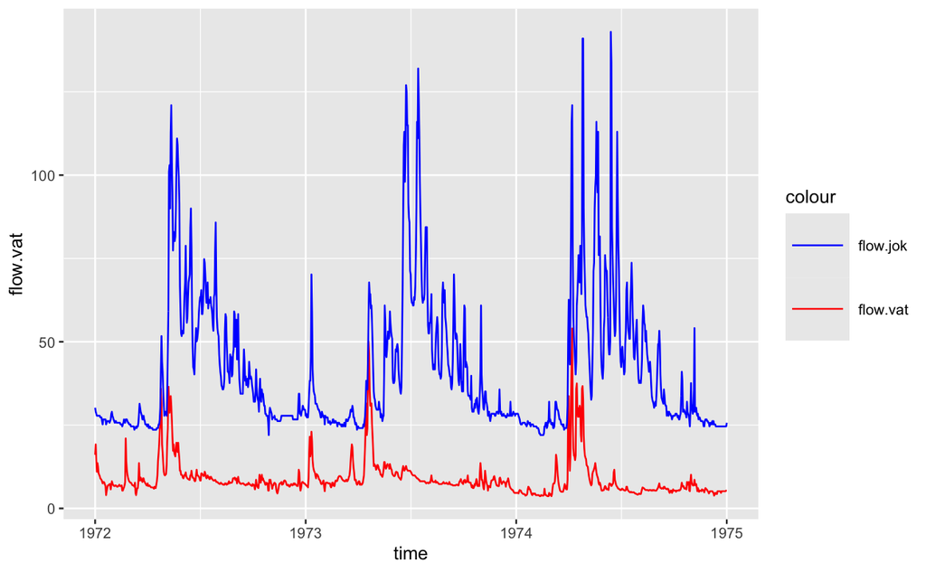

Observamos que el río `flow.jok` (azul) presenta un caudal mucho mayor al de `flow.vat` (rojo) durante todo el periodo analizado, que transcurre desde 1972 hasta 1975.

## 6.3 Utiliza la función labs para enriquecer el gráfico.

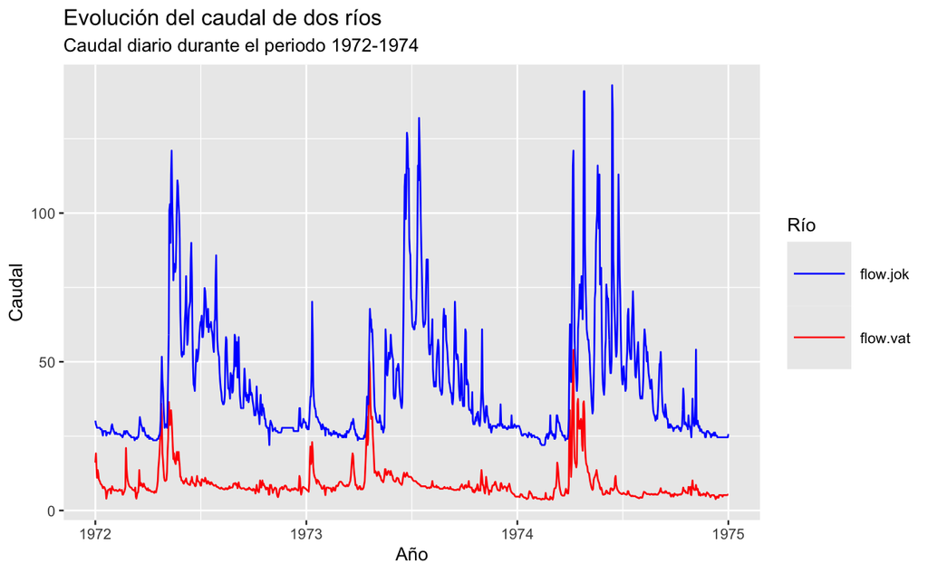

## 6.4 Almacena en formato pdf el gráfico resultante en un fichero denominado Ejercicio6.pdf.

# 7 Ejercicio 7

## 7.1 Carga el fichero weatherAUS_distributions.RData.

```
[1] "ds"
```

```
'data.frame':   863 obs. of  24 variables:
 $ Year         : Factor w/ 11 levels "2008","2009",..: 2 7 3 6 5 10 10 7 7 2 ...
 $ Location     : chr  "Richmond" "Albury" "Launceston" "Sale" ...
 $ MinTemp      : num  14.2 13.9 0.4 0.2 10.2 9 8.6 24 12.4 24.4 ...
 $ MaxTemp      : num  29.8 27.7 13.1 15.1 20.7 17.2 23.9 34.2 18 31.9 ...
 $ Rainfall     : num  0.2 1.4 0 0.2 0 1 0 0 2 18.4 ...
 $ Evaporation  : chr  "12.2" NA NA "1.2" ...
 $ Sunshine     : chr  NA NA NA "7.3" ...
 $ WindGustDir  : chr  "NE" "W" "S" "NW" ...
 $ WindGustSpeed: int  28 37 19 17 NA 44 63 41 NA 31 ...
 $ WindDir9am   : chr  NA "ENE" NA "WNW" ...
 $ WindDir3pm   : chr  "E" "NW" "SSE" "NNW" ...
 $ WindSpeed9am : int  0 6 0 9 6 22 13 15 6 11 ...
 $ WindSpeed3pm : int  11 22 4 7 13 30 39 15 35 17 ...
 $ Humidity9am  : int  92 74 98 93 64 71 62 71 84 83 ...
 $ Humidity3pm  : int  36 42 57 57 40 63 22 56 61 68 ...
 $ Pressure9am  : num  1017 1008 1028 1024 1025 ...
 $ Pressure3pm  : num  1014 1007 1026 1021 1020 ...
 $ Cloud9am     : int  NA NA NA 2 5 3 2 6 7 6 ...
 $ Cloud3pm     : int  NA 5 NA 3 7 8 1 3 3 6 ...
 $ Temp9am      : num  18.3 20.9 4.3 3.7 13 12.8 15.4 29.7 15.3 27.9 ...
 $ Temp3pm      : num  29.5 26.4 11.9 14.3 18.7 14.6 23.5 32.1 17.5 30.9 ...
 $ RainToday    : chr  "No" "Yes" "No" "No" ...
 $ RISK_MM      : num  0 0 0.4 0 0 0.2 0 0 1.6 24.2 ...
 $ RainTomorrow : chr  "No" "No" "No" "No" ...
 - attr(*, "spec")=
  .. cols(
  ..   Date = col_date(format = ""),
  ..   Location = col_character(),
  ..   MinTemp = col_double(),
  ..   MaxTemp = col_double(),
  ..   Rainfall = col_double(),
  ..   Evaporation = col_character(),
  ..   Sunshine = col_character(),
  ..   WindGustDir = col_character(),
  ..   WindGustSpeed = col_integer(),
  ..   WindDir9am = col_character(),
  ..   WindDir3pm = col_character(),
  ..   WindSpeed9am = col_integer(),
  ..   WindSpeed3pm = col_integer(),
  ..   Humidity9am = col_integer(),
  ..   Humidity3pm = col_integer(),
  ..   Pressure9am = col_double(),
  ..   Pressure3pm = col_double(),
  ..   Cloud9am = col_integer(),
  ..   Cloud3pm = col_integer(),
  ..   Temp9am = col_double(),
  ..   Temp3pm = col_double(),
  ..   RainToday = col_character(),
  ..   RISK_MM = col_double(),
  ..   RainTomorrow = col_character()
  .. )
```

## 7.2 Crea un gráfico en el que estén los boxplots de la variable MinTemp para cada uno de los años presentes en la variable Year del dataset.

Usamos la función `geom_boxplot()`.

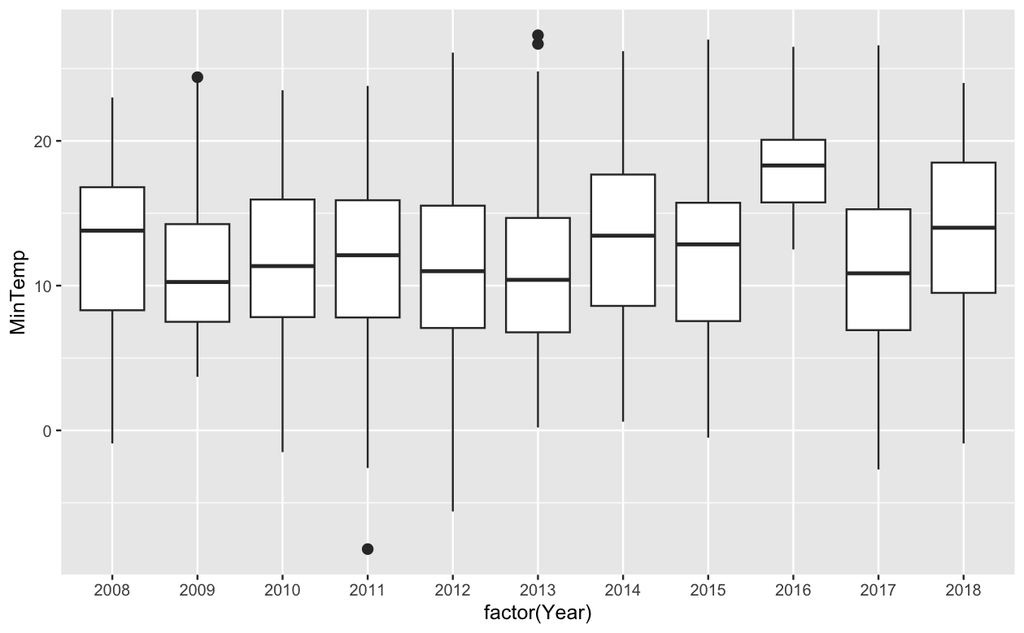

Observamos que las temperaturas mínimas presentan distribuciones relativamente similares, con algunas diferencias en sus medianas y dispersión. Destaca 2016, que presenta la mediana más elevada y una menor dispersión.

## 7.3 Crea un gráfico en el que estén los gráficos de violín de la variable MaxTemp para cada uno de los años presentes en la variable Year del dataset. Añade en el mismo gráfico una capa de etiquetas de título (Distribución de temperaturas máximas por año), eje x (Año) y eje y (Temperatura (ºC)). Colorea el interior de los violines según la la variable Year.

Utilizamos la función `geom_violin()`.

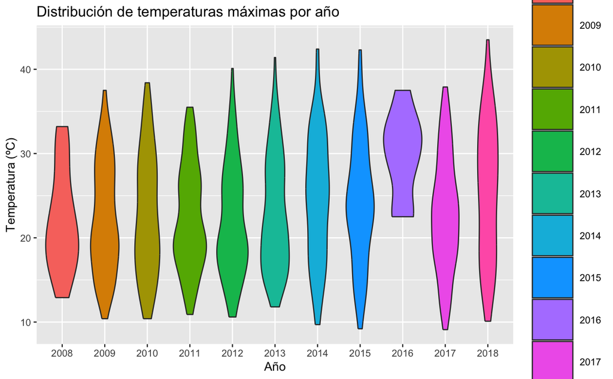

Observamos que las temperaturas máximas presentan distribuciones diferentes según el año. En general, hay una mayor concentración de valores entre los 15 y 30 grados.

Destaca, una vez más, 2016, con temperaturas más elevadas y concentradas, mientras que otros años presentan distribuciones más amplias.

## 7.5 Almacena en formato pdf el gráfico resultante en un fichero denominado Ejercicio7.pdf.